# <font color="red"> Lecture 6 – ANOVA and Linear Models</font>

## STAT/BIOF/GSAT 540: Statistical Methods for High Dimensional Biology

### Keegan Korthauer

### 2020/01/22 <br><br> <font size="5"> Slides by: Gabriela Cohen Freue with contributions from Jenny Bryan and Keegan Korthauer </font>

### <font color="red"> Are these genes truly different in NrlKO compared to WT?</font>

### H<sub>0</sub>: the expression level of gene A is the same in both conditions.

### Is there **enough** evidence in the data to reject H<sub>0</sub>?

[figure not shown]

### **Statistics**: use a random sample to learn about the population

[figure not shown]

# Last class: hypothesis testing

### 1. Define a <font color = "red">test statistic</font> to test `\(H_0\)`

- 2-sample *t*-test
- Welch *t*-test
- Wilcoxon rank-sum test
- Kolmogorov-Smirnov test

### 2. Compute the <font color=red>observed value</font> for the test statistic

### 3. Compute the probability of seeing a test statistic as extreme as that observed, under the <font color = "red">null sampling distribution</font> (p-value)

### 4. Make a decision about the <font color = "red">significance</font> of the results, based on a pre-specified value (alpha, significance level)

## We can run these tests in R

### Example: use the `t.test` function to test `\(H_0\)` using a classical 2-sample *t*-test.

```r
miniDat %>% subset(gene == "Irs4") %>% t.test(gExp ~ gType, data = .,
    var.equal = TRUE)
```

```
##
## 	Two Sample t-test
##
## data:  gExp by gType
## t = -0.52865, df = 37, p-value = 0.6002
## alternative hypothesis: true difference in means is not equal to 0
## 95 percent confidence interval:
##  -0.12597002  0.07383844
## sample estimates:
## mean in group NrlKO    mean in group wt
##            7.739684            7.765750
```

# Today...

### - show how to compare means of different groups (2 or more) using a linear regression model

- dummy variables to model the levels of a qualitative explanatory variable

### - write a linear model using matrix notation

- understand which matrix is built by R

### - distinguish between conditional and marginal effects

- `\(t\)`-tests vs `\(F\)`-tests

[figure not shown]

It seems that we can use any of these methods to test `\(H_0\)`

[figure not shown]

## *t*-test *vs* linear regression: <font color = "red">why the same results?</font>

```r
irs4Dat <- subset(miniDat,gene=="Irs4")
ttest.irs4<-t.test(gExp ~ gType, irs4Dat, var.equal = TRUE)
list("t value"=ttest.irs4$stat,"p-value"=ttest.irs4$p.value)
```

```
## $`t value`
##          t
## -0.5286494
##
## $`p-value`
## [1] 0.6002058
```

```r
lm.irs4 <- summary(lm(gExp ~ gType, irs4Dat))
list("t value"=lm.irs4$coeff[2,3],"p-value"=lm.irs4$coeff[2,4])
```

```
## $`t value`
## [1] 0.5286494
##
## $`p-value`
## [1] 0.6002058
```

## *t*-test *vs* linear regression: <font color = "red">where's the line?</font>

[figure not shown]

> Note that the `\(y\)`-axis in these plots is not numerical, thus a line in this space does not have any mathematical meaning.

### Why can we run a `\(t\)`-test with a <font color = "red">linear</font> regression model?

# From *t*-test to linear regression

Let's change the notation to give a common framework to all methods

 `$$Y \sim G; \; E[Y] = \mu_Y$$`
 **↓**

`$$Y = \mu_Y + \varepsilon_Y; \; \varepsilon_Y \sim G; \; E[\varepsilon_Y] = 0$$`

We can use a subindeces to distinguish observations from each group, i.e.,

`$$Y_{ij} = \mu_j + \varepsilon_{ij};\; \; \varepsilon_{ij} \sim G_j; \; \;E[\varepsilon_{ij}] = 0;$$`

where `\(j = \textrm{\{wt, NrlKO}\}\)` or `\(j=\textrm{\{1, 2}\}\)` identifies the groups;
and `\(i=1, \ldots, n_j\)` identifies the observations within each group

> For example: `\(Y_{11}\)` is the first observation in group 1 or WT

## The goal is to test

### `$$H_0 : \mu_1 = \mu_2$$`

### using data from the model

`$$Y_{ij} = \mu_j + \varepsilon_{ij};\; \; \varepsilon_{ij} \sim G; \; \;E[\varepsilon_{ij}] = 0;$$`

where `\(j = \textrm{\{wt, NrlKO}\}\)` or `\(j=\textrm{\{1, 2}\}\)`; and `\(i=1, \ldots, n_j\)`.

> For simplicity, we assume a common distribution `\(G\)` for all groups

### Note that the population means are given by `\(E[Y_{ij}] = \mu_j\)`, i.e., the model is written with a <font color = "red">cell-means</font> - `\(\mu_j\)` - parametrization

### Note that for each group, the <font color = "red">population</font> mean is given by

### `$$E[Y_{ij}] = \mu_j,$$`

###A natural **estimator** of the population mean is the **sample mean**

### Classical hypothesis testing methods use the group sample means as estimators

See, for example, the `t.test` function in R:

```r
ttest.irs4$estimate
```

```
## mean in group NrlKO    mean in group wt
##            7.739684            7.765750
```

### However, the `lm` function reports other estimates, <font color = "red">why?</font>

```r
(means.irs4 <- as.data.frame(irs4Dat %>% group_by(gType) %>%
    summarize(meanGroups = mean(gExp, digits = 6))))
```

```
##   gType meanGroups
## 1 NrlKO   7.739684
## 2    wt   7.765750
```

```r
lm.irs4$coefficients[,1]
```

```
## (Intercept)     gTypewt
##  7.73968421  0.02606579
```

`\(\hspace{3em}\)` **↓**

`(Intercept)` is the sample mean of NrlKO group

but `gTypewt` is not the sample mean of the WT group

### Parametrizations: which parameters we use to write the model?

<Big>
By default, the `lm` does not use the cell-means parametrization
The goal is to *compare* the means, not to study each in isolation

From **cell-means** - `\(\mu_j\)`:  `$$Y_{ij} = \mu_j + \varepsilon_{ij};\; \; \varepsilon_{ij} \sim G; \; \;E[\varepsilon_{ij}] = 0;$$`

**↓**

to **reference-treatment effect** - `\((\theta,\tau_j)\)`: `$$Y_{ij} = \theta+\tau_j + \varepsilon_{ij};\; \; \tau_1=0, \; \; \varepsilon_{ij} \sim G; \; \;E[\varepsilon_{ij}] = 0;$$`

Note that for each group, the population mean is given by
`$$E[Y_{ij}] = \theta+\tau_j=\mu_j,$$`
and `\(\tau_2=\mu_2-\mu_1=E[Y_{i2}] -E[Y_{i1}]\)` *compares* the means

## Relation between parametrizations

[figure not shown]

### `lm` reports the sample mean of the <font color = "red">reference</font> group (NrlKO): `\(\hat\theta\)`

### and the <font color = "red">treatment effect</font>, i.e., difference between the sample means of both groups: `\(\hat\tau_2\)`

```r
lm.irs4$coefficients[, 1]
```

```
## (Intercept)     gTypewt
##  7.73968421  0.02606579
```

```r
data.frame(meanWT = means.irs4[1, 2],
    meanDiff = diff(means.irs4$meanGroups))
```

```
##     meanWT   meanDiff
## 1 7.739684 0.02606579
```

## We still haven't answered ... where's the line??

<Big>
`$$Y_{ij} = \theta+\tau_j + \varepsilon_{ij};\; \; \tau_1=0, \; \; \varepsilon_{ij} \sim G; \; \;E[\varepsilon_{ij}] = 0;$$`

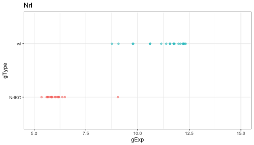

# <font color="red">Dummy</font> variables

<Big>

Let's re-write our model using dummy (or indicator) variables:

`$$Y_{ij} = \theta+\tau_j + \varepsilon_{ij};\; \; \tau_1=0, \; \; \varepsilon_{ij} \sim G; \; \;E[\varepsilon_{ij}] = 0;$$`
**↓**

`$$Y_{ij} = \theta+\tau_2 \times x_{ij} + \varepsilon_{ij};\; \; x_{ij}=\bigg\{\begin{array}{l}
1\text{ if } j=2\\
0 \text{ otherwise}\\
\end{array}$$`

> Note that `\(Y_{i1} = \theta + \varepsilon_{i1}\)`, because `\(\tau_1=0\)` and `\(x_{i1}=0\)`
> and `\(Y_{i2} = \theta + \tau_2+ \varepsilon_{i2}\)`, because `\(x_{i2}=1\)` (for all `\(i\)`)

The second form is written as a linear ( `\(y=a + bx +\varepsilon\)` ) regression, with a special (dummy) explanatory variable  `\(x_{ij}\)`

### Using a dummy variables to model our categorical variables `gtype` we can perform a  <font color = "red">2-sample *t*-test</font> with a linear model

`$$Y_{ij} = \theta+\tau_2 \times x_{ij} + \varepsilon_{ij};\; \; x_{ij}=\bigg\{\begin{array}{l}
1 \text{ if } j=2\\
0 \text{ if } j=1\\
\end{array}$$`

```r
list("t value"=ttest.irs4$stat,"p-value"=ttest.irs4$p.value)
```

```
## $`t value`
##          t
## -0.5286494
##
## $`p-value`
## [1] 0.6002058
```

```r
list("t value"=lm.irs4$coeff[2,3],"p-value"=lm.irs4$coeff[2,4])
```

```
## $`t value`
## [1] 0.5286494
##
## $`p-value`
## [1] 0.6002058
```

## Beyond 2-groups comparisons: difference of means

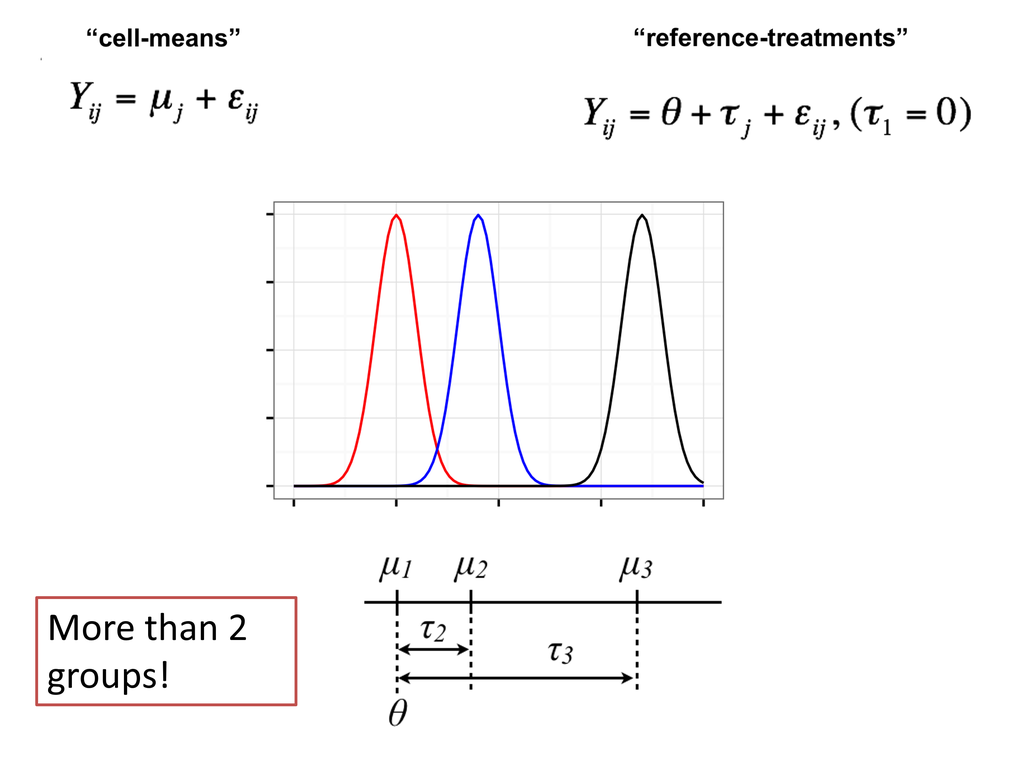

### Dummy variables can be used to model one *or more* categorical variables with 2 *or more* levels!

### <font color = "red">2-sample *t*-test</font> using a linear model

`$$Y_{ij} = \theta+\tau_2 \times x_{ij} + \varepsilon_{ij};\; \; x_{ij}=\bigg\{\begin{array}{l}
1 \text{ if } j=2\\
0 \text{ if } j=1\\
\end{array}$$`

### This is why R can estimate all of them with `lm()`

`\(^{(*)}\)` in general, *yet* another parametrization is used to present ANOVA

## <font color = "red">t-test</font>

> Special case of ANOVA, but with ANOVA you can compare **more than two groups** and **more than one factor**.

## <font color = "red">ANOVA</font>

> Special case of linear regression, but with linear regression you can include **quantitative variables** in the model.

## <font color = "red">Linear regression</font>

> Provides a unifying framework to model the association between a response **many quantitative and qualitative variables**.

### <font color = "red">In R</font>: all can be computed using the `lm()` function.